# Graphical display of raster data

Advanced Geospatial Data Processing for Social Scientists

Dennis Abel & Stefan Jünger

2026-06-09

## Now

| Day | Time | Title |
| --- | --- | --- |
| June 9 | 10:00–11:15 | Introduction |
| June 9 | 11:15–11:30 | Coffee Break |
| June 9 | 11:30–13:00 | Raster data in R |
| June 9 | 13:00–14:00 | Lunch Break |
| June 9 | 14:00–15:15 | Raster data processing |
| June 9 | 15:15–15:30 | Coffee Break |
| June 9 | 15:30–17:00 | Graphical display of raster data in maps |
| June 10 | 10:00–11:15 | Datacube processing I |
| June 10 | 11:15–11:30 | Coffee Break |
| June 10 | 11:30–13:00 | Datacube processing II & API access |
| June 10 | 13:00–14:00 | Lunch Break |
| June 10 | 14:00–15:15 | Data integration and linking (with survey data) |
| June 10 | 15:15–15:30 | Coffee Break |
| June 10 | 15:30–17:00 | Outlook and open session with own application |

## Why should we use data visualization?

In general:

- contribute to a **better understanding** of your analysis results
- understand your data in the first place

Generating a plot is easy as you will see

… Making **good plots**, however, can take a while

## Visual display of quantitative information

Check out [Edward Tufte’s](https://www.edwardtufte.com/tufte/) work on data visualization to achieve **graphical excellence**. It is a *minimalist* approach to visualization which **maximizes the proportion of data-ink** to total ink in a plot. [Tufte in R](http://motioninsocial.com/tufte/) offers many examples how to translate Tufte’s perspective into graphs in R.

[figure not shown]

[Source](https://www.edwardtufte.com/tufte/)

**“The Leonardo da Vinci of data.”** - *THE NEW YORK TIMES*

## Avoid chartjunk

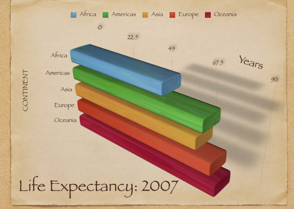

Source: [Healy 2018, Ch 1, Figure 1.4: A chart with a considerable amount of junk in it](https://socviz.co/lookatdata.html)

## Reduce data-ink example

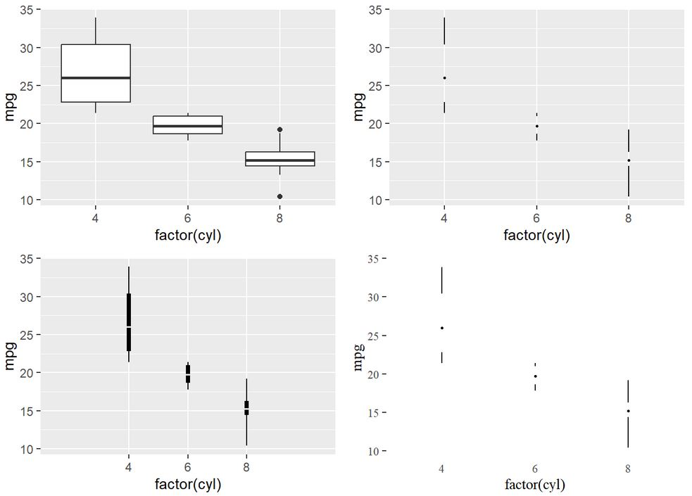

Source: https://bookdown.org/paul/applied-data-visualization/03-the-quality-of-graphs.html#fig-tufte-boxplot

## What is `ggplot2`?

In general, `ggplot2` is well-suited for **multi-dimensional data** like raster layers and stacks.

Components of the plot are added as layers.

```r
plot_call +
  layer_1 +
  layer_2 +
  ... +
  layer_n
```

If you are new to `ggplot2`, you might want to check out:

- [ggplot2 - Elegant Graphics for Data Analysis](https://www.springer.com/gp/book/9783319242750) by Hadley Wickham
- [BBC Visual and Data Journalism cookbook for R graphics](https://bbc.github.io/rcookbook/#how_to_create_bbc_style_graphics)

## Components of a Plot

According to Wickham (2010, p. 8<sup>1</sup>), a layered plot consists of the following components:

- Data and aesthetic mappings,
- Geometric objects,
- Scales,
- (and facet specification)

```r
plot_call +
  data +
  aesthetics +
  geometries +
  scales +
  facets
```

[^1]: Wickham, Hadley. 2010. “A Layered Grammar of Graphics.” Journal of Computational and Graphical Statistics 19(1):3–28. doi: 10.1198/jcgs.2009.07098.

## Recap: Plotting vector data

Load the data

```r
# load district shapefile
german_districts <- sf::read_sf("./data/boundaries/VG250_KRS.shp")

# load district attributes
attributes_districts <-
  readr::read_csv2("./data/misc/attributes_districts.csv") |>
  dplyr::mutate(ecar_share = as.numeric(ecar_share))

# join data
german_districts_enhanced <-
  german_districts |>
  dplyr::left_join(attributes_districts, by = "AGS")

# load states shapefile
german_states <- sf::read_sf("./data/boundaries/VG250_LAN.shp")
```

## Adding geoms to a blank canvas

```r
# a simple first map
ggplot(data = german_districts_enhanced)
```

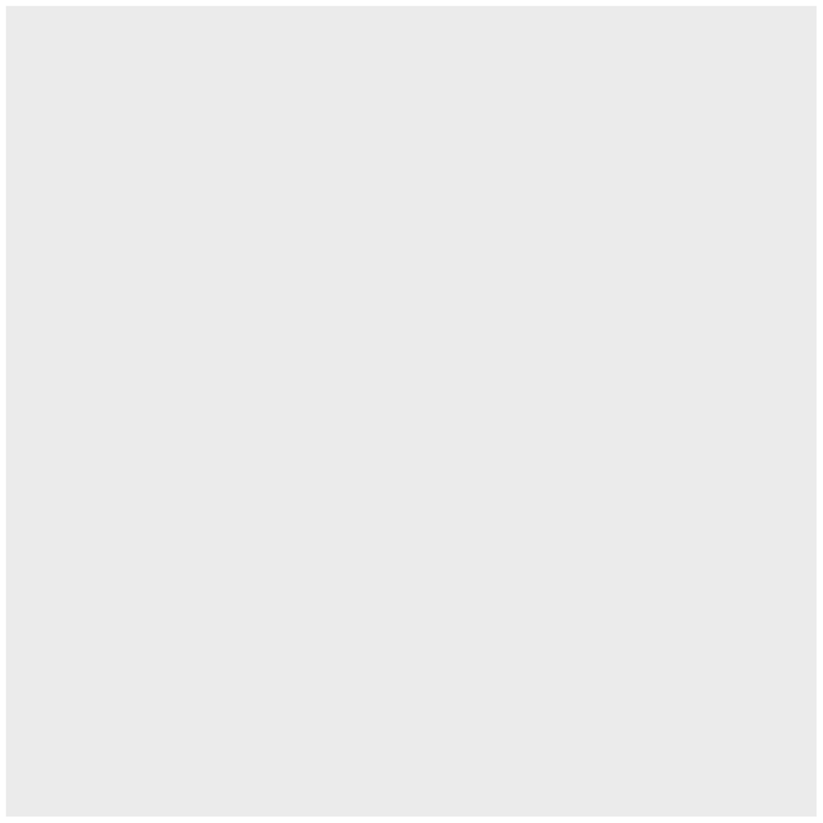

## Adding geoms to a blank canvas

```r
# a simple first map
ggplot() +
  geom_sf(data = german_districts_enhanced)
```

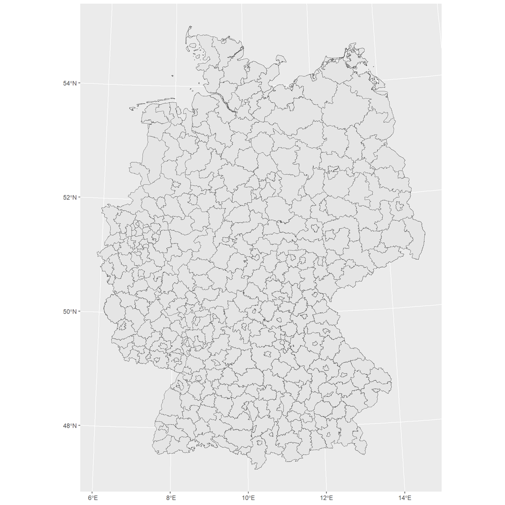

## Add the `aesthetics`

Are you having trouble choosing the right color? Some excellent tutorials exist, f.e, by [Michael Toth](https://michaeltoth.me/a-detailed-guide-to-ggplot-colors.html).

```r
# change color palette
ggplot() +
  geom_sf(
    data = german_districts_enhanced,
    aes(fill = ecar_share)
  ) +
  # readable with color vision deficiencies
  scale_fill_viridis_c(option = "plasma", direction = -1)
```

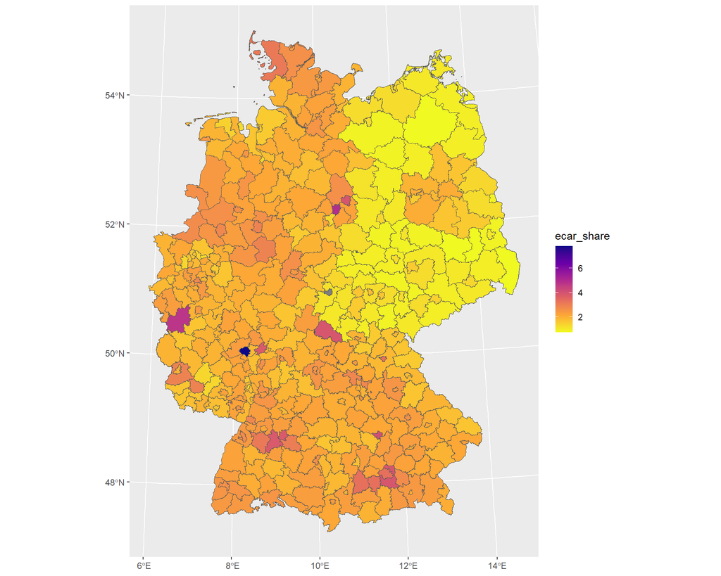

## Add another layer

```r
# the shapefile includes polygons of oceans and lakes
# easy fix on the fly when you know your data
german_states <-
  german_states |>
  dplyr::filter(GF == 4)

# add layer with German states
ggplot() +
  geom_sf(
    data = german_districts_enhanced,
    aes(fill = ecar_share),
    color = NA
  ) +
  scale_fill_viridis_c(
    option = "plasma",
    direction = -1
  ) +
  # add another layer
  geom_sf(
    data = german_states,
    # filling transparent
    fill = "transparent",
    # color of borders
    color = "black",
    # size of borders
    size = 1
  )
```

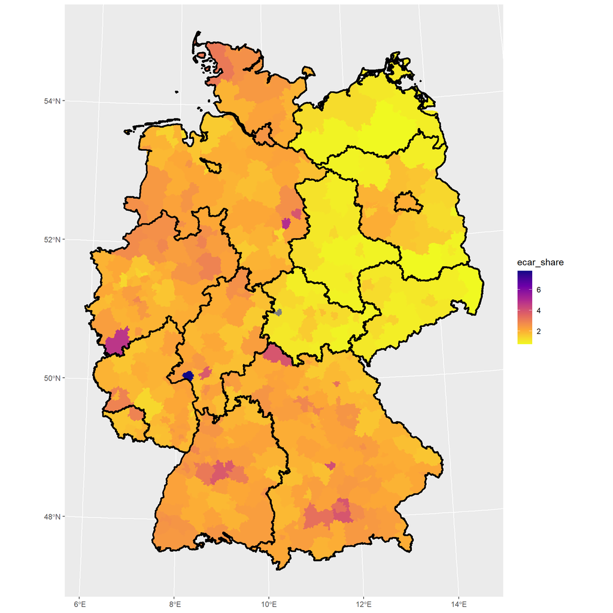

## Save and reuse

Maps produced with `ggplot2` are standard objects like any other object in `R` (they are lists). We can assign them to reuse, plot later, and add map layers.

Furthermore, you can save them just as any `ggplot2` graph. The `ggsave()` function automatically detects the file format. You can also define the height, width, and dpi, which is particularly useful to produce high-class graphics for publications.

## Save and reuse

```r
# assign to object
ecar_map <-
  ggplot() +
  geom_sf(
    data = german_districts_enhanced,
    aes(fill = ecar_share),
    color = NA
  ) +
  scale_fill_viridis_c(
    option = "plasma",
    direction = -1,
    name = "E-Car Share",
    guide = guide_legend(
      direction= "horizontal",
      label.position = "bottom"
    )
  ) +
  geom_sf(
    data = german_states,
    fill = "transparent",
    color = "black"
  )

# save as png-file
# ggsave("ecar_map.png", ecar_map, dpi = 300)
```

## Where `ggplot2` cannot help anymore

In some specific circumstances, we might realize that `ggplot2` is super powerful but not originally designed to build maps. Typical features of maps are not in the package, like a compass or scale bars.

This is where other packages might need to be installed. The good thing: Elements of the package `ggspatial` can be included as `ggplot2` layer. Check out [Github](https://paleolimbot.github.io/ggspatial/).

## The extras

`ggspatial` allows you to add, f.e. a scale bar and a north arrow.

```r
# add scalebar and north arrow
ecar_map +
  ggspatial::annotation_scale(
    location = "br"
  ) +
  ggspatial::annotation_north_arrow(
    location = "tr",
    style = ggspatial::north_arrow_minimal()
  )
```

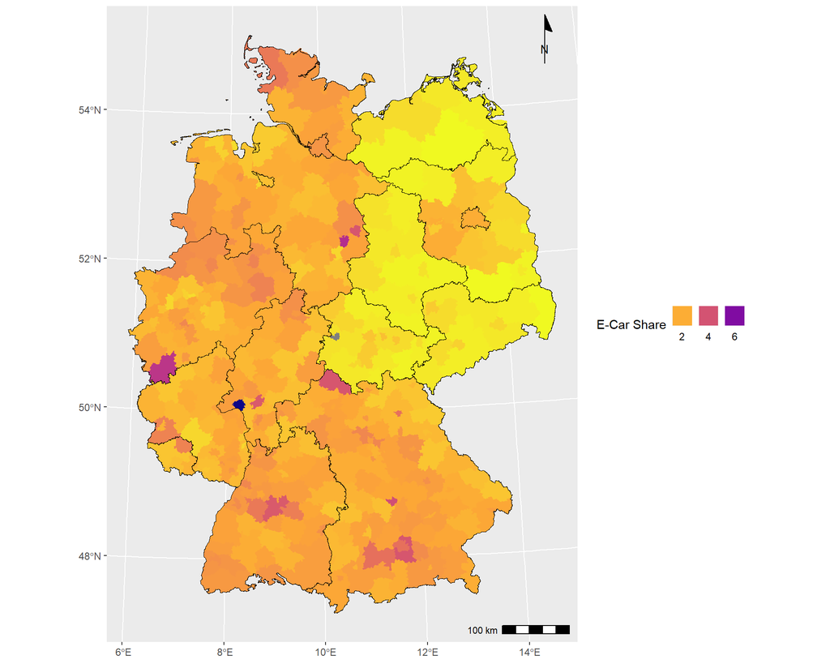

## Making a plan

This map will be our canvas for the ongoing session. There are hundreds of options to change this map. We will cover at least some essential building blocks:

- *THE MAP*: adding attributes, choosing from colors/palettes, adding layers
- *THE LEGEND*: position, sizes, display
- *THE ENVIRONMENT*: choosing from themes and build your own
- *THE META-INFORMATION*: titles and sources
- *THE EXTRAS*: scales and compass

If you are working on your maps, the [ggplot2 cheatsheets](https://rstudio.github.io/cheatsheets/html/data-visualization.html) will help you with an overview of scales, themes, labels, facets, and more.

## `ggplot2` and raster data

You can perfectly use `ggplot2` to create maps with raster data. There are several ways to do so. The easiest way is using the `tidyterra` package.

```r
library(tidyterra)

# Create random raster
r <- terra::rast(nrows = 50,
                 ncols = 50,
                 xmin = 0,
                 xmax = 10,
                 ymin = 0,
                 ymax = 10
                 )
terra::values(r) <- runif(terra::ncell(r))

# Plot with tidyterra::geom_spatraster
ggplot() +
  geom_spatraster(data = r) +
  scale_fill_viridis_c(na.value = "transparent") +
  theme_minimal()
```

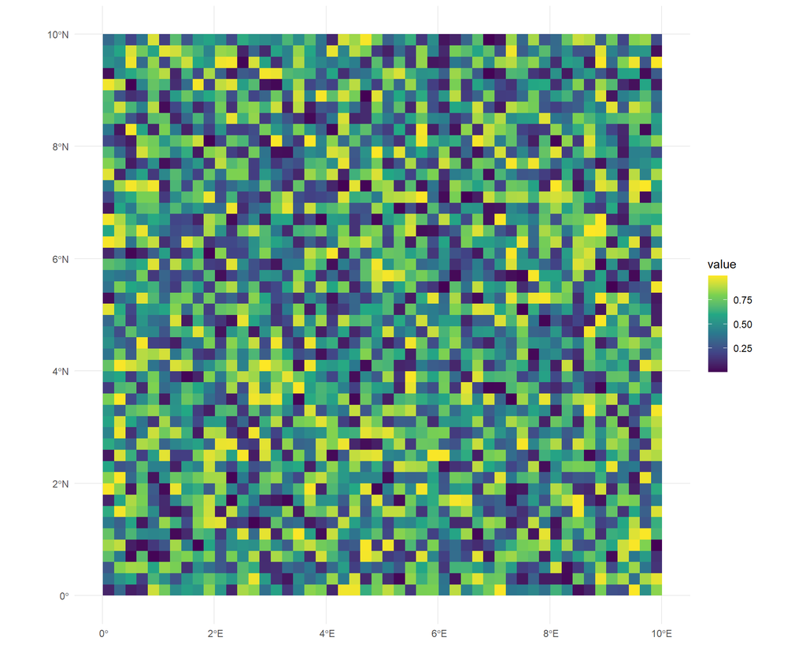

## Case study: Population dynamics

Let’s explore the suitability of `ggplot2` in combination with `tidyterra` with a case study on population dynamics in Germany. We are utilizing the population grids from the [WorldPop Open Population Repository (WOPR)](https://www.worldpop.org/).

```r
# Example with worldpop data for Germany 2020
ger_pop_2020 <- terra::rast("./data/worldpop/deu_ppp_2020_1km_Aggregated.tif")

ger_pop_2020
```

```
class       : SpatRaster
size        : 934, 1100, 1  (nrow, ncol, nlyr)
resolution  : 0.008333333, 0.008333333  (x, y)
extent      : 5.87375, 15.04042, 47.27458, 55.05792  (xmin, xmax, ymin, ymax)
coord. ref. : lon/lat WGS 84 (EPSG:4326)
source      : deu_ppp_2020_1km_Aggregated.tif
name        : deu_ppp_2020_1km_Aggregated
min value   :                       0.000
max value   :                    4513.521
```

## Simple plot with `terra`/`base` `R`

```r
terra::plot(ger_pop_2020)
```

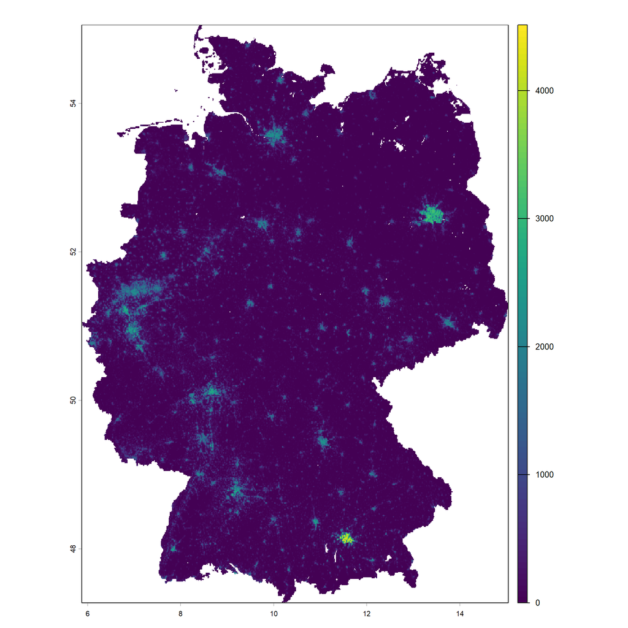

## Simple plot with `terra`/`base` `R`

Let’s transform it into ETRS89/UTM 32N (EPSG: 25832). You will detect a slight adjustment to the visualization.

```r
ger_pop_2020 <- terra::project(ger_pop_2020,
                               "EPSG:25832"
                               )

terra::plot(ger_pop_2020)
```

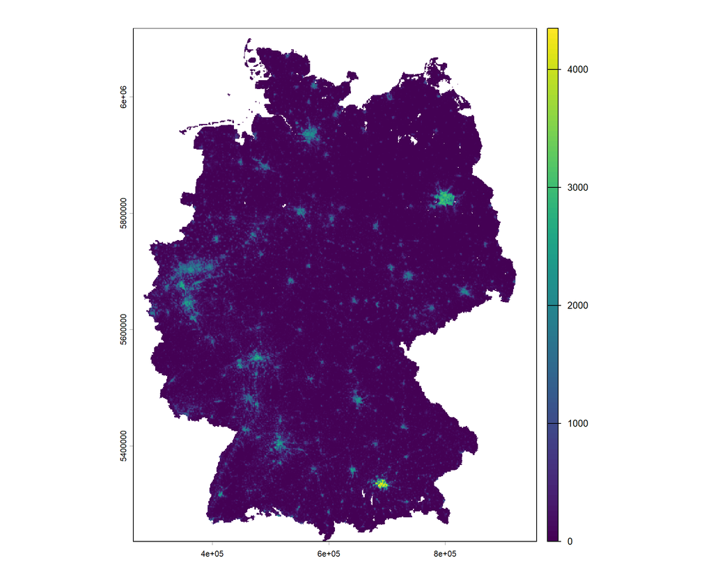

## Let’s turn to `ggplot`

```r
ggplot()+
  geom_spatraster(data = ger_pop_2020)
```

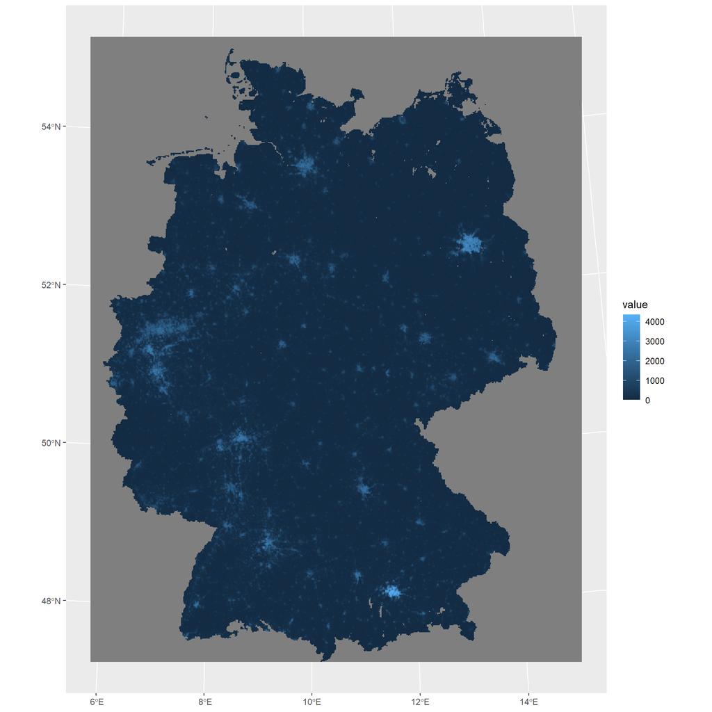

## Let’s turn to `ggplot`

Adjust the color scheme

```r
ggplot()+
  geom_spatraster(data = ger_pop_2020)+
  scale_fill_whitebox_c(
    palette = "muted",
    n.breaks = 12,
    guide = guide_legend(reverse = TRUE)
  )
```

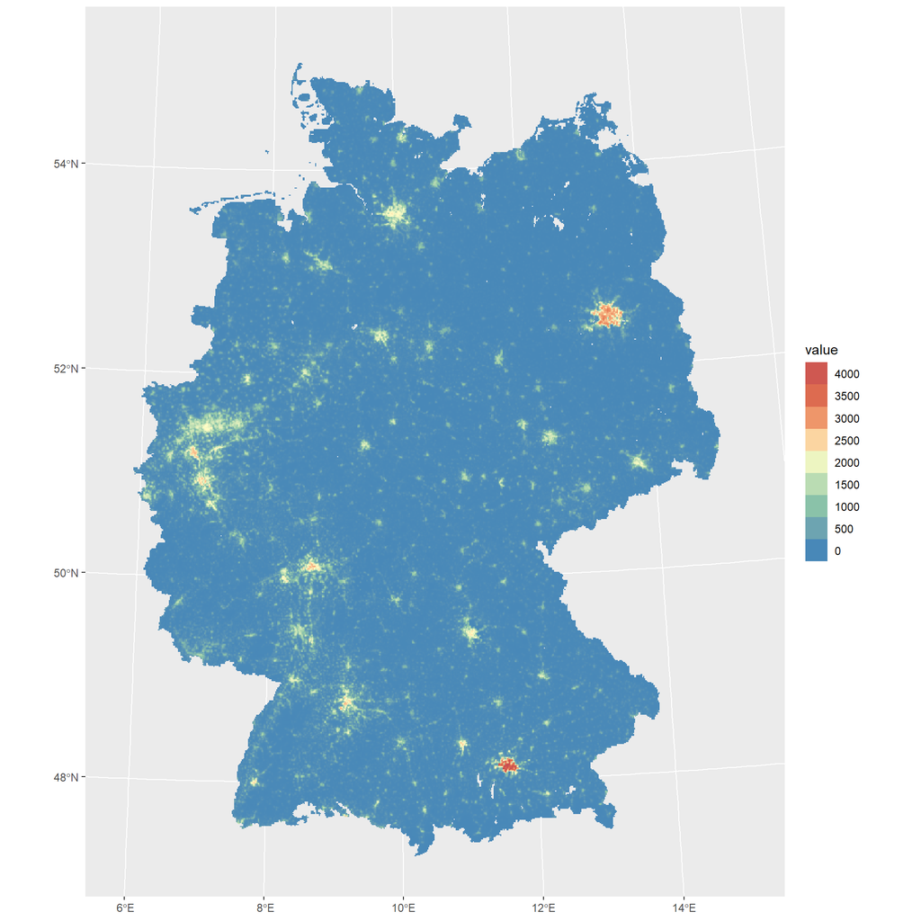

## Let’s turn to `ggplot`

Adjust the color scheme

```r
ggplot()+
  geom_spatraster(data = ger_pop_2020)+
  scale_fill_viridis_c(
    n.breaks = 12,
    guide = guide_legend(reverse = TRUE)
  )
```

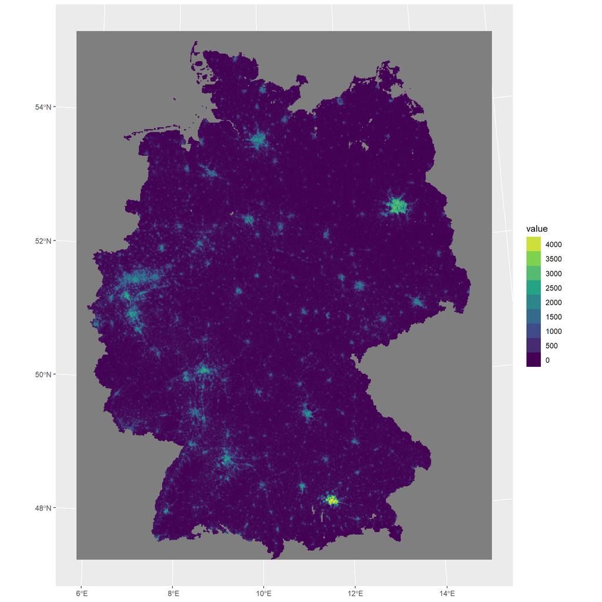

## Let’s turn to `ggplot`

Add labels

```r
ggplot()+
  geom_spatraster(data = ger_pop_2020)+
  scale_fill_viridis_c(
    n.breaks = 12,
    guide = guide_legend(reverse = TRUE)
  )+
  labs(
    fill = "Population\ncount",
    title = "Estimated population of Germany in 2020",
    subtitle = "Approx. 1km grid"
  )
```

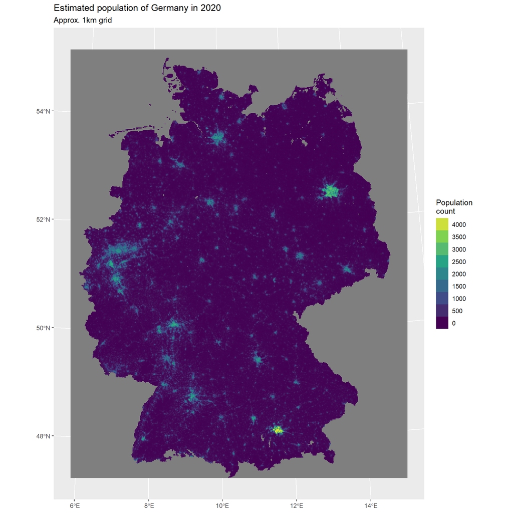

## Exercise 4_1: A simple map

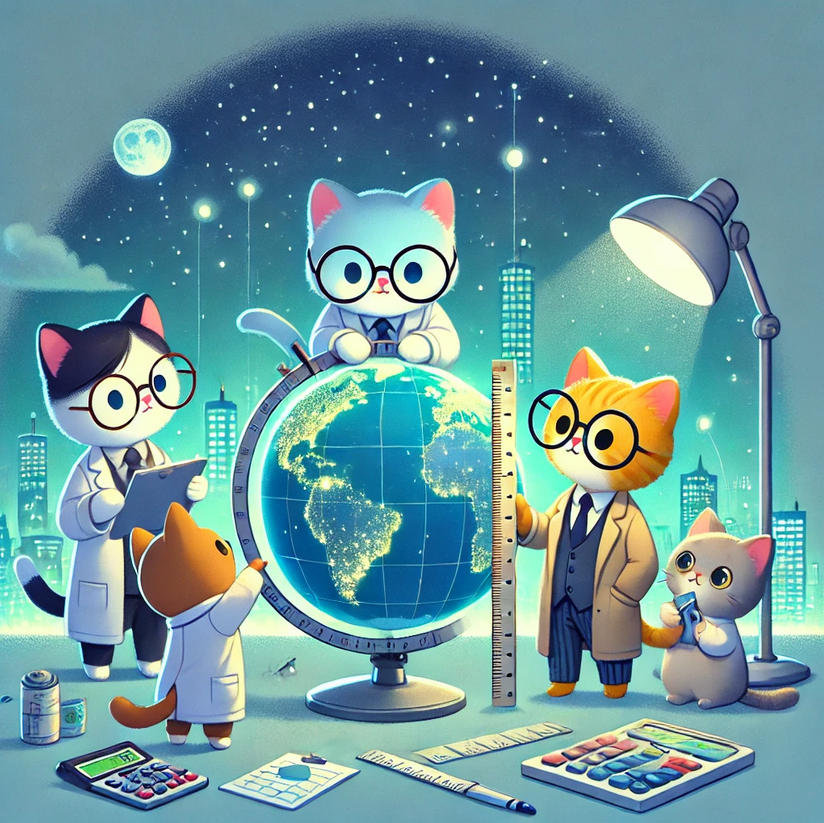

## Case study: Population dynamics

We will now dig deeper into population dynamics. We load a **second layer** which records the population size twenty years earlier - in 2000. We compare dimensions of both layers: they match.

```r
ger_pop_2000 <- terra::rast("./data/worldpop/deu_ppp_2000_1km_Aggregated.tif") |>
  terra::project("EPSG:25832")

ger_pop_2000
```

```
class       : SpatRaster
size        : 1183, 930, 1  (nrow, ncol, nlyr)
resolution  : 745.5165, 745.5165  (x, y)
extent      : 263554.6, 956885, 5235978, 6117924  (xmin, xmax, ymin, ymax)
coord. ref. : ETRS89 / UTM zone 32N (EPSG:25832)
source(s)   : memory
name        : deu_ppp_2000_1km_Aggregated
min value   :                       0.000
max value   :                    3343.013
```

```r
ger_pop_2020
```

```
class       : SpatRaster
size        : 1183, 930, 1  (nrow, ncol, nlyr)
resolution  : 745.5165, 745.5165  (x, y)
extent      : 263554.6, 956885, 5235978, 6117924  (xmin, xmax, ymin, ymax)
coord. ref. : ETRS89 / UTM zone 32N (EPSG:25832)
source(s)   : memory
name        : deu_ppp_2020_1km_Aggregated
min value   :                       0.000
max value   :                    4395.625
```

## Case study: Population dynamics

We calculate simple differences for each cell between 2020 and 2000 to detect increases and decreases in estimated population per cell.

```r
ger_pop_diff <- ger_pop_2020 - ger_pop_2000

terra::plot(ger_pop_diff)
```

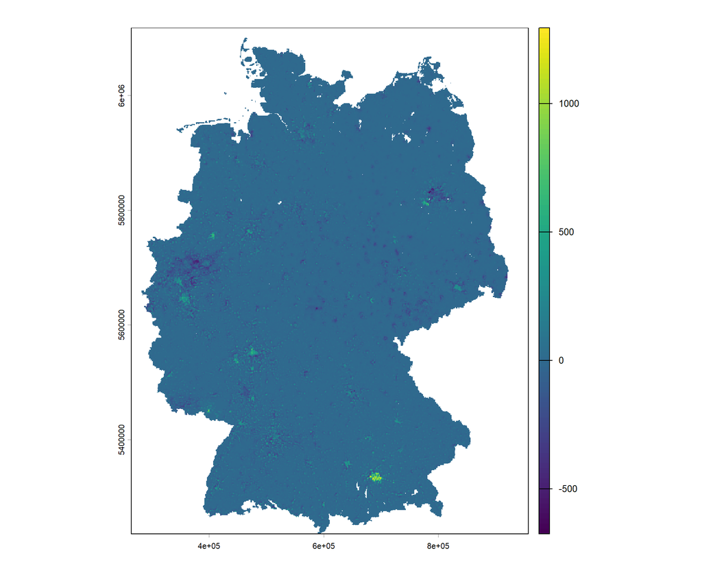

## Case study: Population dynamics

The state (Bundesland) of North Rhine-Westphalia looks quite interesting. The state has both growth and decline regions. We zoom into that region and explore dynamics within and between districts (Kreise).

```r
NRW_districts <- sf::read_sf("./data/boundaries/VG250_KRS.shp") |>
  filter(SN_L == "05")

ggplot(NRW_districts)+
  geom_sf(aes(fill = BEZ))
```

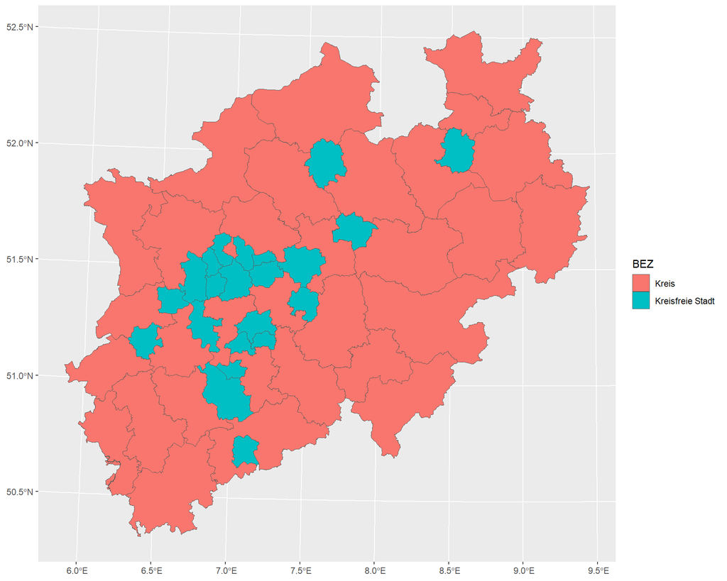

## Case study: Population dynamics

The state (Bundesland) of North Rhine-Westphalia looks quite interesting. The state has both growth and decline regions. We zoom into that region and explore dynamics within and between districts (Kreise).

```r
# Subset pop data to spatial extent of NRW
NRW_pop_diff <- terra::crop(
  ger_pop_diff,
  NRW_districts
) |>
  terra::mask(NRW_districts)

# Let's visualize
ggplot()+
  geom_spatraster(data = NRW_pop_diff)+
  geom_sf(data = NRW_districts,
          fill = "transparent",
          color = "white",
          size = 1)
```

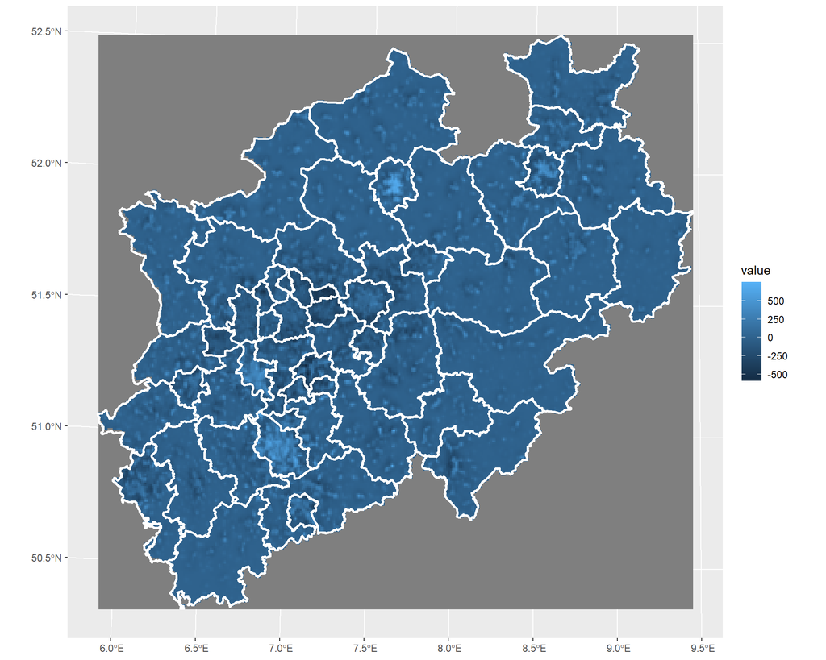

## Case study: Population dynamics

We are now working with diverging values +/-0. The color palette should reflect that. We have several options to adjust it.

```r
ggplot()+
  geom_spatraster(data = NRW_pop_diff)+
  geom_sf(data = NRW_districts,
          fill = "transparent",
          color = "white",
          size = 1)+
  scale_fill_viridis_c(option = "magma")
```

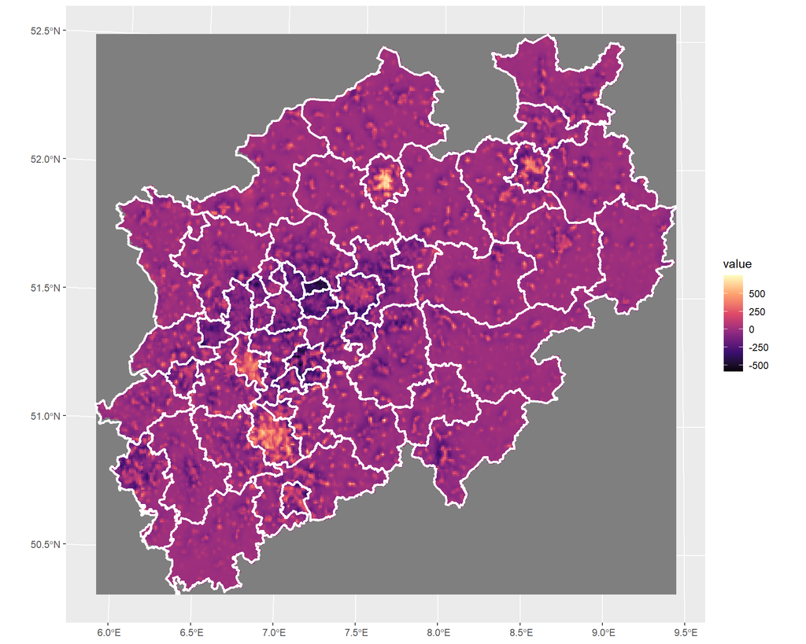

## Case study: Population dynamics

We are now working with diverging values +/-0. The color palette should reflect that. We have several options to adjust it.

```r
# Identify max and min to adjust for skewness of positive and negative values
max_val <- max(abs(minmax(NRW_pop_diff)))

ggplot()+
  geom_spatraster(data = NRW_pop_diff)+
  geom_sf(data = NRW_districts,
          fill = "transparent",
          color = "black",
          size = 1)+
  scale_fill_distiller(type = "div",
                       palette = "PuOr",
                       limits = c(-max_val, max_val)
                       )
```

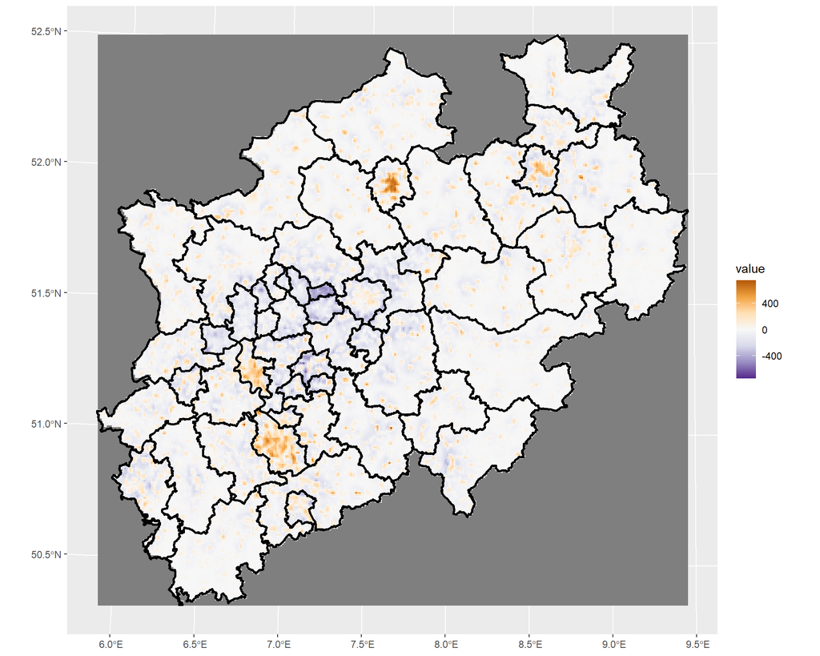

## Case study: Population dynamics

We are now working with diverging values +/-0. The color palette should reflect that. We have several options to adjust it.

```r
# Or define manually for even greater control
ggplot()+
  geom_spatraster(data = NRW_pop_diff)+
  geom_sf(data = NRW_districts,
          fill = "transparent",
          color = "black",
          size = 1)+
  scale_fill_gradient2(
    low = "#2d004b",
    mid = "white",
    high = "#b35806",
    midpoint = 0
  )
```

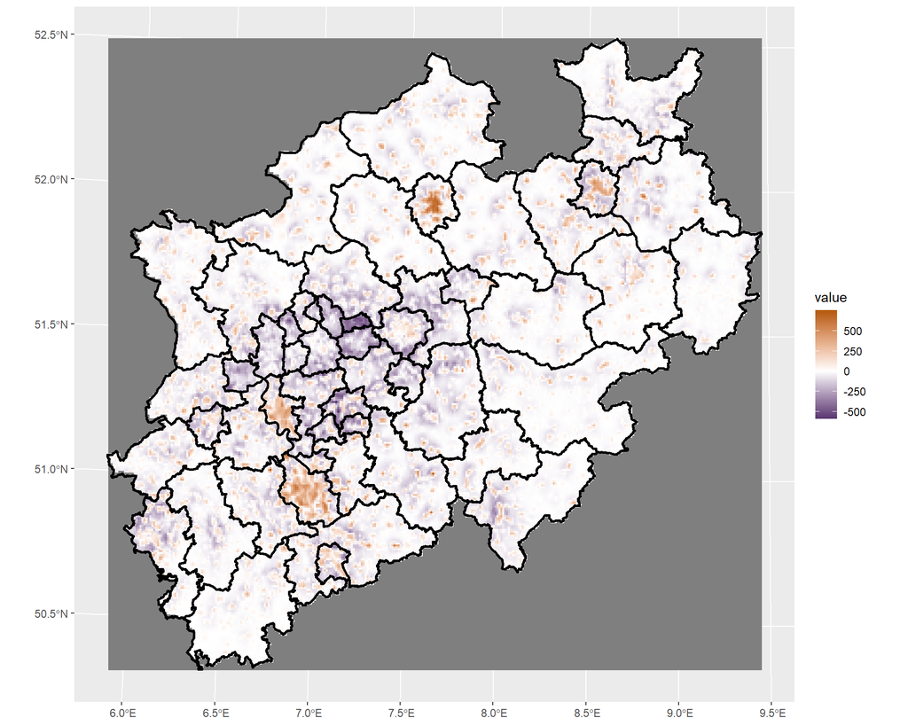

## Case study: Population dynamics

We also want to add text labels for the two districts with the highest population growth and decline.

```r
# Identify growing and shrinking districts
NRW_districts <- NRW_pop_diff |>
  extract(NRW_districts, fun = mean, na.rm =TRUE) |>
  as_tibble() %>%
  bind_cols(NRW_districts, .)

extremes <- NRW_districts |>
  arrange(desc(deu_ppp_2020_1km_Aggregated)) |>
  slice(c(1, n()))
```

## Case study: Population dynamics

We also want to add text labels for the two districts with the highest population growth and decline.

```r
ggplot()+
  geom_spatraster(data = NRW_pop_diff)+
  geom_sf(data = NRW_districts,
          fill = "transparent",
          color = "black",
          size = 1)+
  geom_sf_text(data = extremes,
               aes(label = GEN),
               size = 4,
               color = "black"
               )+
  scale_fill_gradient2(
    low = "#2d004b",
    mid = "white",
    high = "#b35806",
    midpoint = 0
  )
```

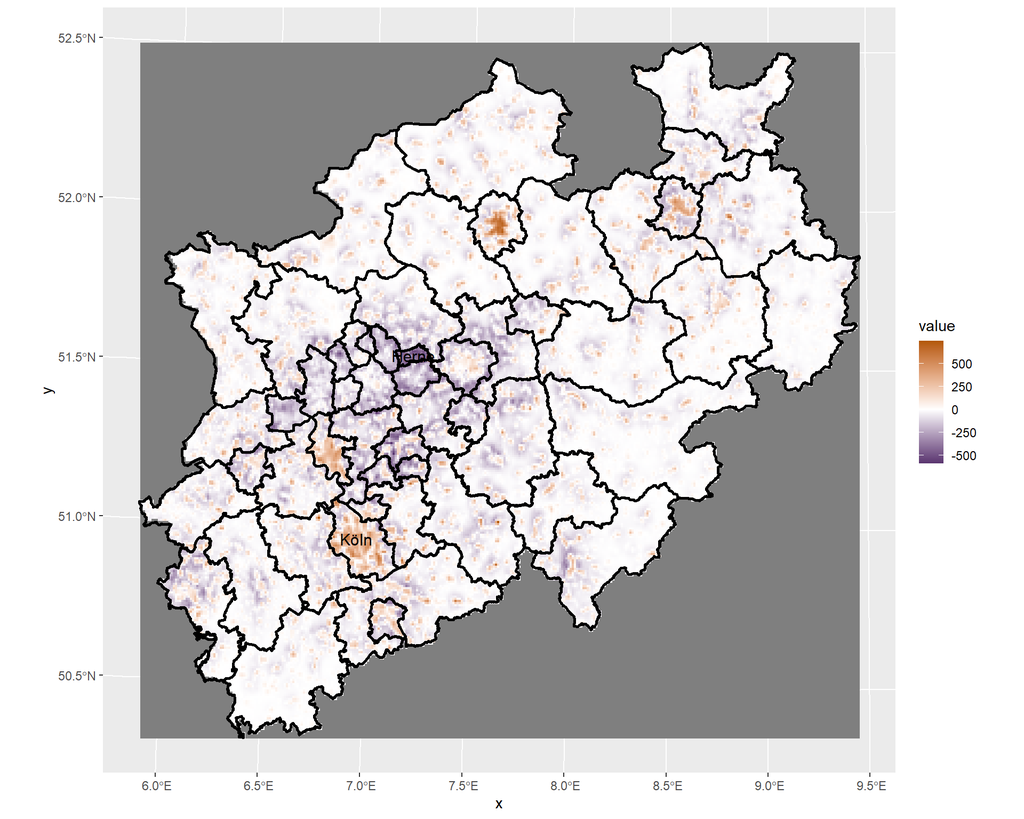

## Case study: Population dynamics

I prefer labels instead of text

```r
library(ggrepel)

ggplot()+
  geom_spatraster(data = NRW_pop_diff)+
  geom_sf(data = NRW_districts,
          fill = "transparent",
          color = "black",
          size = 1)+
  geom_label_repel(
    data = extremes,
    aes(geometry = geometry, label = GEN),
    stat = "sf_coordinates",
    min.segment.length = 0,
    segment.color = "black",
    segment.size = 0.5,
    size = 4,
    fill = "white",
    color = "black",
    label.size = 0.2
    )+
  scale_fill_gradient2(
    low = "#2d004b",
    mid = "white",
    high = "#b35806",
    midpoint = 0
  )
```

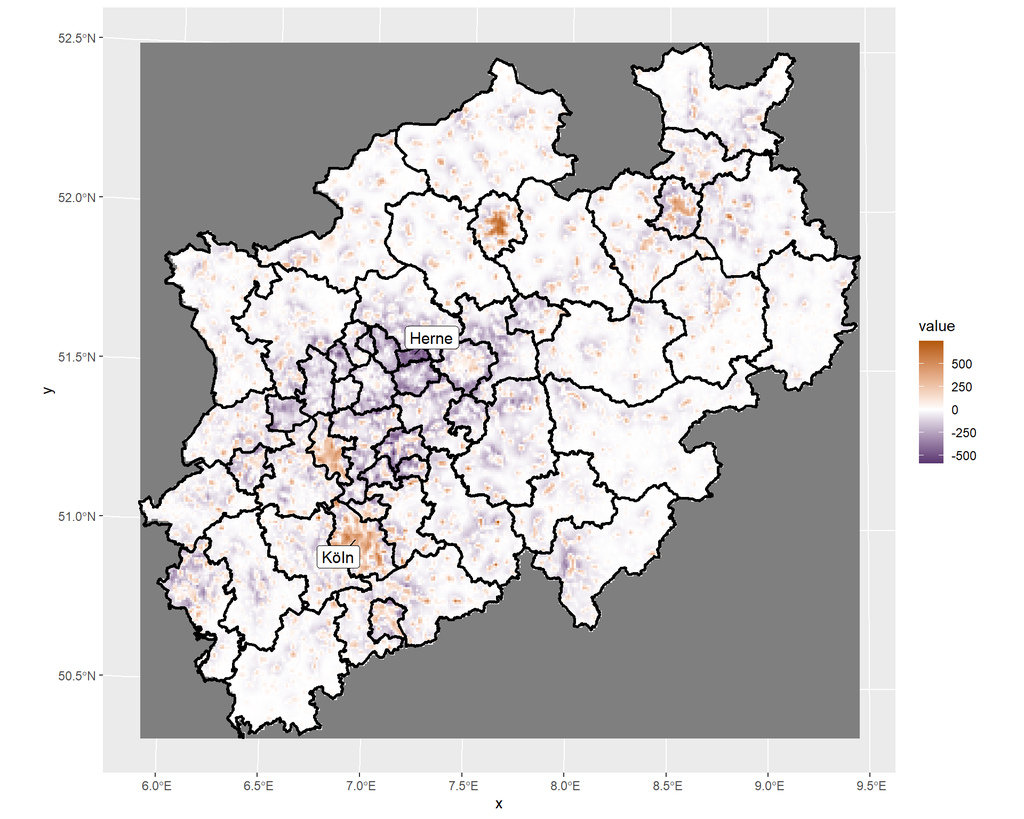

## Case study: Population dynamics

Let’s do some final polishing: 1. Turn **NAs** transparent, 2. add **arrow** and **scale bar**, 3. make final adjustments to the **theme**, and 4. adjust **title, subtitle and caption**.

```r
library(ggspatial)

ggplot()+
  geom_spatraster(data = NRW_pop_diff)+
  geom_sf(data = NRW_districts,
          fill = "transparent",
          color = "black",
          size = 1)+
  geom_label_repel(
    data = extremes,
    aes(geometry = geometry, label = GEN),
    stat = "sf_coordinates",
    min.segment.length = 0,
    segment.color = "black",
    segment.size = 0.5,
    size = 4,
    fill = "white",
    color = "black",
    label.size = 0.2
  )+
  scale_fill_gradient2(
    low = "#2d004b",
    mid = "white",
    high = "#b35806",
    midpoint = 0,
    na.value = "transparent",
    name = "Population\nChange"
  )+
  theme_minimal()+
  theme(
    axis.title = element_blank()
  ) +
  labs(
    title = "Population change in NRW Districts (2000–2020)",
    subtitle = "In absolute numbers on approx. 1km grid\nText labels identify highest growth and decline districts",
    caption = "Source: WorldPop (www.worldpop.org)"
  ) +
  annotation_scale(
    location = "br",
    width_hint = 0.3
  ) +
  annotation_north_arrow(
    location = "tl",
    which_north = "true",
    style = north_arrow_fancy_orienteering
  )
```

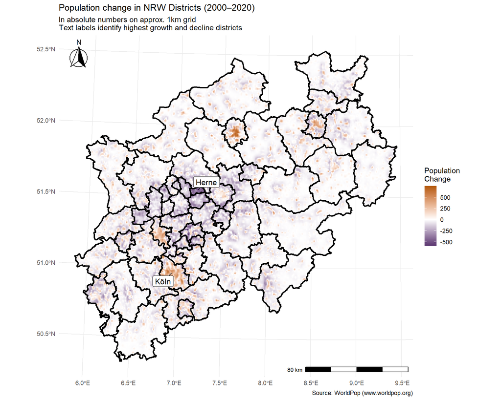

## Beyond raw cell values: Contours

Let’s zoom into Cologne to explore the `geom_spatraster()` options a bit further.

```r
cologne_bbox <- st_bbox(NRW_districts |>
                          filter(GEN == "Köln")
                        )

# Subset pop data to spatial extent of Cologne
koeln_pop_2020 <- terra::crop(
  ger_pop_2020,
  cologne_bbox
)

ggplot()+
  geom_spatraster(data = koeln_pop_2020)+
  scale_fill_viridis_c(
    guide = guide_legend(reverse = TRUE)
  )+
  geom_sf(data = NRW_districts,
          fill = "transparent",
          color = "white",
          size = 1)+
  coord_sf(
    xlim = c(cologne_bbox["xmin"],
             cologne_bbox["xmax"]),
    ylim = c(cologne_bbox["ymin"],
             cologne_bbox["ymax"]),
    expand = FALSE
  )+
  theme_minimal()+
  theme(
    axis.title = element_blank()
  )
```

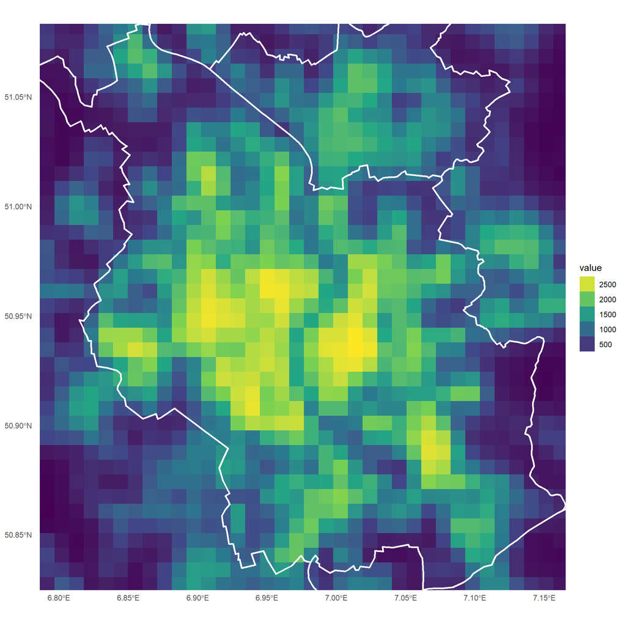

## Beyond raw cell values: Contours

Let’s zoom into Cologne to explore the geom_spatraster options a bit further

```r
# Plot contour
ggplot()+
  geom_spatraster_contour_filled(
    data = koeln_pop_2020
    )+
  scale_fill_viridis_d(
    guide = guide_legend(reverse = TRUE)
  )+
  geom_sf(data = NRW_districts,
          fill = "transparent",
          color = "white",
          size = 1)+
  coord_sf(
    xlim = c(cologne_bbox["xmin"],
             cologne_bbox["xmax"]),
    ylim = c(cologne_bbox["ymin"],
             cologne_bbox["ymax"]),
    expand = FALSE
  )+
  theme_minimal()+
  theme(
    axis.title = element_blank()
  )
```

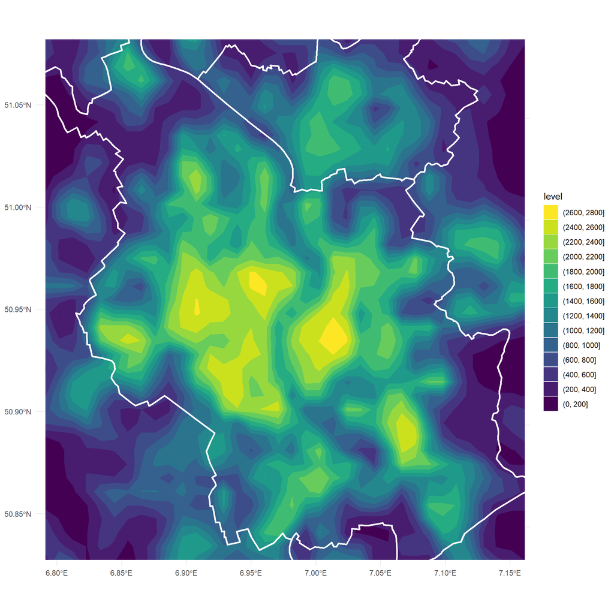

## Exercise 4_2: A fancy map

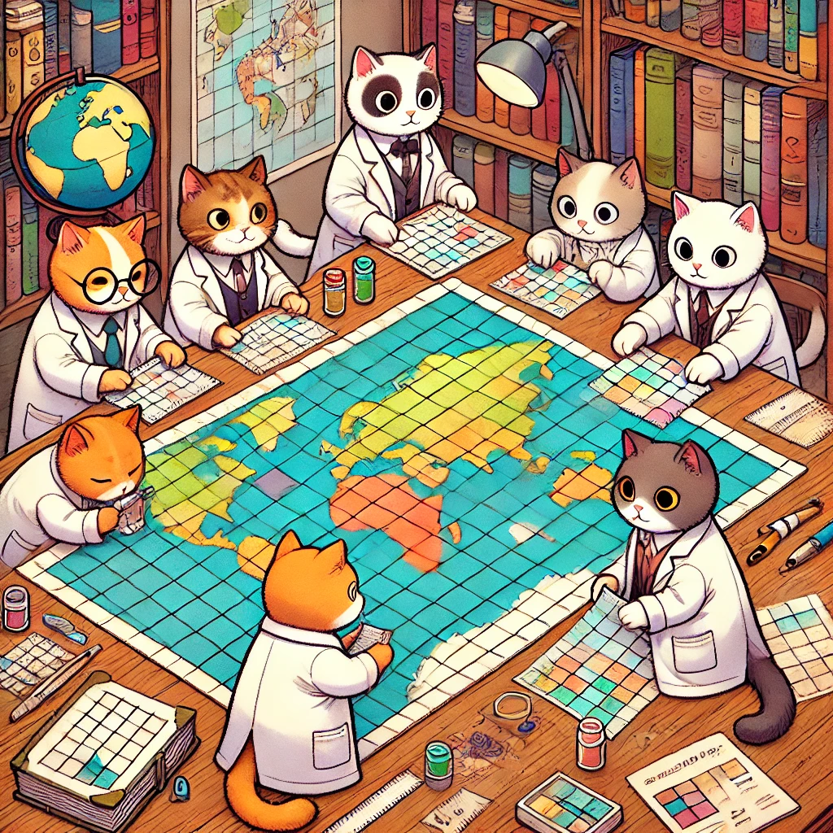